# Projekt nr 2

Antoni Chudy

11 05 2021

# Wstęp

Raport przestawia wyniki otrzymane podczas wykonywania zadanego projektu. Polegał on na tym, że należało rozwiązać 5 zadań podanych w formie zapytań języka SQL za pomocą:

- *funkcji bazowych języka R*
- *pakietu dplyr*
- *pakietu data.table*

W raporcie dla każdego zadania będę wypisywał wynikową ramke danych tylko raz. Poprawność wyników uzyskanych za pomocą napisanych przeze mnie funkcji sprawdzam za pomocą funkcji *all_equal*.

`Na początku wczytuję potrzebne dane oraz ładuję wymagane pakiety`

# Zadania - rozwiązania

## Zadanie 1

**Opis zadania:**

`Szukamy TagName dla każdej z pierwszych 10 największych wartości Count.`

### Rozwiązanie zadania pierwszego

| TagName | Count |
| --- | --- |
| visas | 5271 |
| usa | 2858 |
| air-travel | 2830 |
| uk | 2114 |
| schengen | 2094 |
| customs-and-immigration | 1798 |
| transit | 1204 |
| trains | 1031 |
| passports | 954 |
| indian-citizens | 916 |

### Porównanie otrzymanych wyników

```r
all_equal(df_sql_1(Tags), df_base_1(Tags))
```

```
## [1] TRUE
```

```r
all_equal(df_sql_1(Tags), df_plyr_1(Tags))
```

```
## [1] TRUE
```

```r
all_equal(df_sql_1(Tags), df_table_1(TagsDT))
```

```
## [1] TRUE
```

### Porównanie czasów wykonywania poszczególnych funkcji

```
## Unit: microseconds
##        expr     min       lq      mean   median       uq     max neval
##       sqldf 12770.6 24058.65 26238.774 24510.45 25428.50 74210.9   100
##        base   145.8   259.70   286.615   304.45   318.85   363.5   100
##       dplyr  5749.8 10466.05 11203.577 10852.95 11116.65 59959.9   100
##  data.table  1154.2  2618.45  2699.593  2812.60  2906.80  5025.4   100
```

### Wykres dla uzyskanych wyników

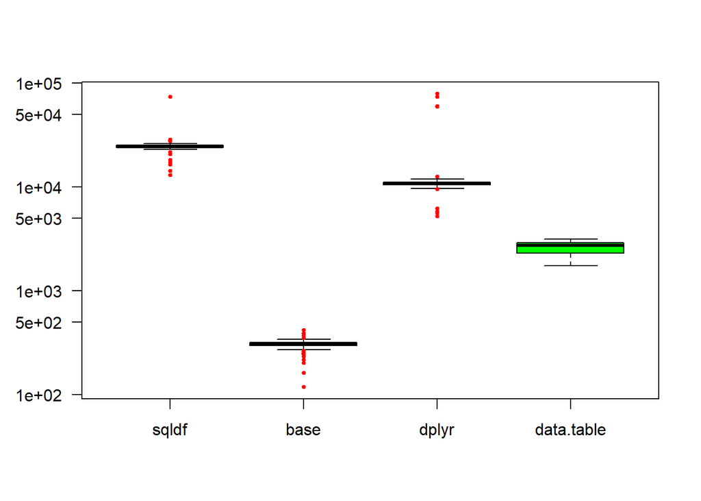

## Zadanie 2

**Opis zadania:**

`Spośród OwnerUserId różnych od -1 i równych co do wartości z AccountId wybieramy 10 tych, z największą` `PostsMeanScore (średnią ze Score) oraz wybieramy także ich LastPostCreationDate oraz odpowiadające im DisplayName,` `Age i Location.`

### Rozwiązanie zadania drugiego

| DisplayName | Age | Location | PostsMeanScore | LastPostCreationDate |
| --- | --- | --- | --- | --- |
| Oded | 44 | London, United Kingdom | 52.0 | 2011-11-03T14:40:36.870 |
| Rook | NA |  | 50.0 | 2016-05-27T03:17:41.753 |
| JPhi1618 | NA | Dallas, Texas, United States | 45.0 | 2015-09-26T17:43:19.090 |
| csmba | 42 | San Francisco, CA | 43.0 | 2012-01-15T14:27:11.070 |
| Petrogad | 32 |  | 41.0 | 2016-04-16T19:44:21.020 |
| Josh | NA | Australia | 33.0 | 2011-12-23T18:16:21.877 |
| Dan Esparza | 43 | Atlanta, GA, United States | 30.0 | 2014-01-26T21:12:59.673 |
| James | NA |  | 29.5 | 2017-05-11T00:13:37.897 |
| Brad Rhoads | NA | Nampa, ID | 29.0 | 2016-04-11T11:10:14.240 |
| Dexter | 34 | London, United Kingdom | 28.5 | 2015-05-06T00:23:36.353 |

### Porównanie otrzymanych wyników

```r
all_equal(df_sql_2(Users, Posts), df_base_2(Users, Posts))
```

```
## [1] TRUE
```

```r
all_equal(df_sql_2(Users, Posts), df_plyr_2(Users, Posts))
```

```
## [1] TRUE
```

```r
all_equal(df_sql_2(Users, Posts), df_table_2(UsersDT, PostsDT))
```

```
## [1] TRUE
```

### Porównanie czasów wykonywania poszczególnych funkcji

```
## Unit: milliseconds
##        expr      min       lq       mean    median         uq       max neval
##       sqldf 300.1456 420.4085  473.10175 492.70340  524.15740  663.7165   100
##        base 788.3436 923.6249 1030.84342 999.33550 1129.05370 2374.1261   100
##       dplyr 243.3834 329.8331  374.01806 387.61530  406.05585  622.7012   100
##  data.table  16.1065  22.0757   28.40434  30.69555   32.48645   59.1369   100
```

### Wykres dla uzyskanych wyników

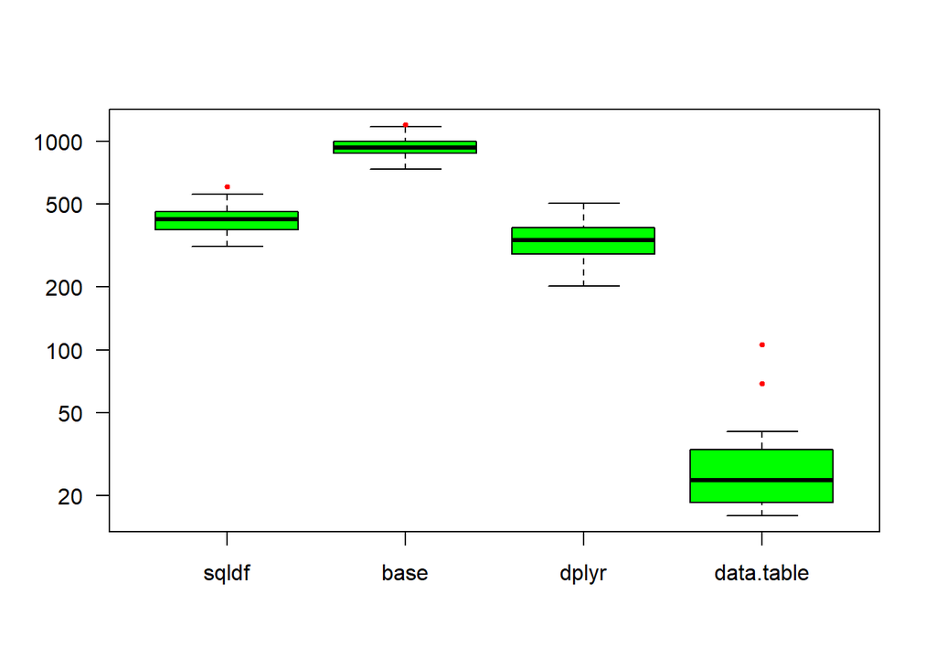

## Zadanie 3 - rozwiązanie

**Opis zadania:**

`Dla tych Id, które są równe co do wartosci z tymi OwnerUserId dla których PostTypeId wynosi 1 liczymy ich` `AnswersNumber czyli ilość wystąpień DisplayName grupując po Id.` `Dla tych Id, które są równe co do wartosci z tymi OwnerUserId dla których PostTypeId wynosi 2 liczymy ich` `QuestionsNumber, czyli ilość ich wystąpień.` `Spośród Id równych z tymi OwnerUserId gdzie PostTypeId jest równy 1 lub 2 wybieramy te, dla których` `QuestionsNumber jest mniejszy niż AnswersNumber. Tak wybrane Id sortujemy malejąco względem ich AnswersNumber,` `a następnie dla tak ustalonego porządku wybieramy ich DisplayName, QuestionsNumber oraz AnswersNumber.`

Wynikowa ramka danych zawiera ponad 400 wierszy dlatego, mając na uwadze czytelność i przejrzystość raportu, wypiszę tylko 10 pierwszych wierszy - poprawność otrzymanych pełnych wyników jest sprawdzana za pomocą funkcji *all_equal*.

### Rozwiązanie zadania trzeciego**

| DisplayName | QuestionsNumber | AnswersNumber |
| --- | --- | --- |
| hippietrail | 257 | 441 |
| RoflcoptrException | 206 | 238 |
| Andrew Grimm | 49 | 212 |
| nsn | 90 | 174 |
| Ivan | 71 | 122 |
| Blaszard | 44 | 80 |
| Adrien Be | 62 | 79 |
| neubert | 31 | 73 |
| shirish | 5 | 67 |
| Canada - Area 51 Proposal | 1 | 61 |

### Porównanie otrzymanych wyników

```r
all_equal(df_sql_3(Users, Posts), df_base_3(Users, Posts))
```

```
## [1] TRUE
```

```r
all_equal(df_sql_3(Users, Posts), df_plyr_3(Users, Posts))
```

```
## [1] TRUE
```

```r
all_equal(df_sql_3(Users, Posts), df_table_3(UsersDT, PostsDT))
```

```
## [1] TRUE
```

### Porównanie czasów wykonywania poszczególnych funkcji

```
## Unit: milliseconds
##        expr      min       lq     mean   median       uq       max neval
##       sqldf 326.4954 430.8667 478.7029 486.0129 523.1028  675.6971   100
##        base 625.6688 752.1660 832.7522 832.0774 914.8676 1111.4077   100
##       dplyr 108.0084 157.9885 195.0682 192.5410 224.2086  342.6391   100
##  data.table 124.9115 194.9584 238.4425 230.9773 276.9658  462.2043   100
```

### Wykres dla uzyskanych wyników

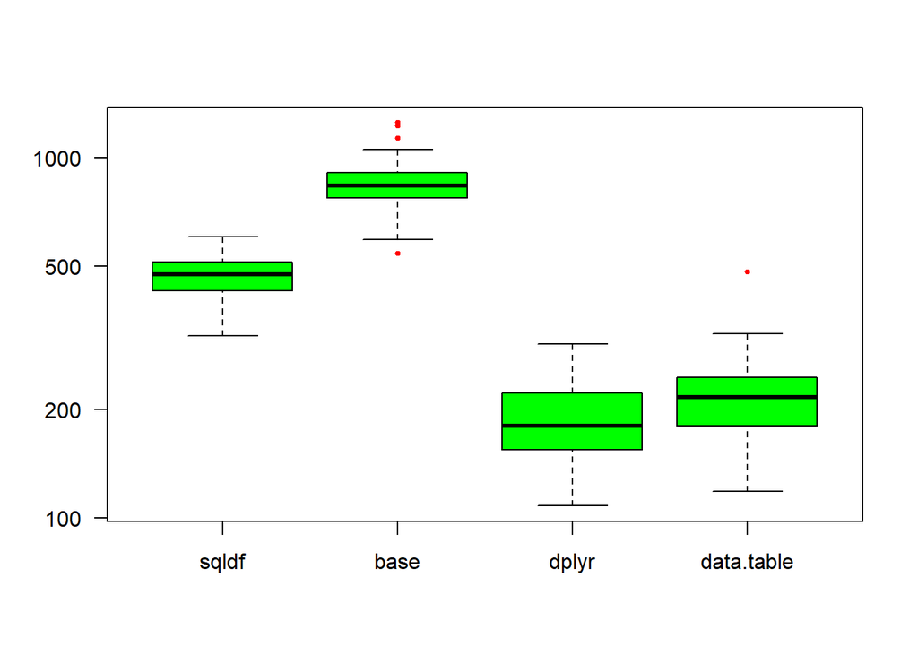

## Zadanie 4 - rozwiązanie

**Opis zadania**:

`Dla unikatowych par PostId, UserId sumując ich Score obliczamy CommentsTotalScore i spośród Id (dla których` `PostTypeId jest równe 1) równych co do wartości PostId wybieramy te 10 Id równych ParentId, dla których` `CommentsTotalScore ma największą wartość oraz dla tak wybranych 10 Id wybieramy odpowiadający im Title,` `CommentCount, ViewCount oraz CommentsTotalScore.`

**Rozwiązanie zadania czwartego**

| Title | CommentCount | CommentsTotalScore | ViewCount |
| --- | --- | --- | --- |
| Boss is asking for passport, but it has a stamp in it I don’t want him to see. What to do? | 24 | 207 | 54982 |
| Why don’t airlines have backup planes just in case of an emergency? | 26 | 172 | 14516 |
| OK we’re all adults here, so really, how on earth should I use a squat toilet? | 27 | 155 | 73808 |
| How to cross a road by foot in a country that drives on the “other” side of the road | 25 | 140 | 5240 |
| Where can I change my clothes at the airport? | 16 | 128 | 12020 |
| Boss is asking for passport, but it has a stamp in it I don’t want him to see. What to do? | 24 | 121 | 54982 |
| How to avoid toddlers on a long-distance plane flight? | 19 | 120 | 24955 |
| Job interview in London requires me to wire money to the travel agent. Is this a scam? | 23 | 116 | 14827 |
| What to do without underwear on a 4 day trip? | 13 | 110 | 11713 |
| OK, we are all adults here, so what is a bidet for and how do I use it? | 28 | 109 | 52265 |

### Porównanie otrzymanych wyników

```r
all_equal(df_sql_4(Posts, Comments), df_base_4(Posts, Comments))
```

```
## [1] TRUE
```

```r
all_equal(df_sql_4(Posts, Comments), df_plyr_4(Posts, Comments))
```

```
## [1] TRUE
```

```r
all_equal(df_sql_4(Posts, Comments), df_table_4(PostsDT, CommentsDT))
```

```
## [1] TRUE
```

### Porównanie czasów wykonywania poszczególnych funkcji

```
## Unit: milliseconds
##        expr       min         lq       mean     median        uq       max
##       sqldf  411.2580  419.83030  491.59720  424.91530  558.8334 1355.5078
##        base 2938.7601 3018.84030 3364.79483 3062.25750 3267.0188 4806.1662
##       dplyr  260.5489  319.02980  382.03740  345.16900  419.8058  671.8130
##  data.table   51.4881   59.42615   83.06435   66.24245  101.0738  184.2886
##  neval
##    100
##    100
##    100
##    100
```

### Wykres dla uzyskanych wyników

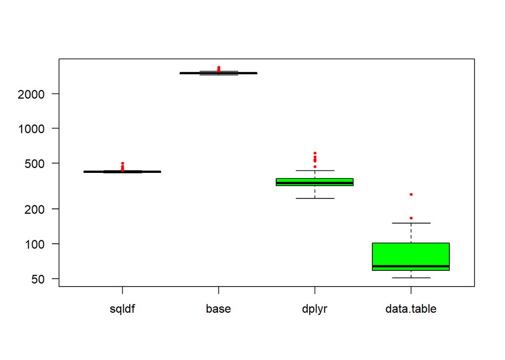

## Zadanie 5 - rozwiązanie

**Opis zadania**:

`Spośród Id dla których PostTypeId jest równe 2 wybieramy te, które są równe z ParentId dla których PostTypeId` `jest równy 1. Następnie dla tak wybranych Id rozpatrujemy ich AcceptedAnswerId i wybieramy Id, Title i MaxScore` `tych AcceptedAnswerId, które są równe z Id z Posts oraz wybieramy też Score z Posts dla Id z Posts równych` `wybranym AcceptedAnswerId. Obliczamy różnicę z MaxScore i Score i spośród wybranych wcześniej Id, Title, MaxScore` `i Posts wybieramy te, które odpowiadają 10 najwiekszym wartościom tej różnicy.`

**Rozwiązanie zadania piątego**

| Id | Title | MaxScore | AcceptedScore | Difference |
| --- | --- | --- | --- | --- |
| 99713 | In Germany, what are you supposed to do if your train station doesn’t have any working ticket machines? | 126 | 33 | 93 |
| 81376 | What is way to eat rice with hands in front of westerners such that it doesn’t appear to be yucky? | 120 | 30 | 90 |
| 76737 | Why do many countries in the world still require citizens of states with a high HDI to get visas? | 118 | 31 | 87 |
| 38177 | How do you know if Americans genuinely/literally mean what they say? | 245 | 166 | 79 |
| 90636 | Caught speeding 111 Mph (179 km/h) in California. How can I settle the case with the court? | 101 | 25 | 76 |
| 81492 | Why is international first class much more expensive than international economy class? | 90 | 21 | 69 |
| 94320 | Strange looking region of France on Google Maps | 71 | 7 | 64 |
| 80050 | What’s an easy way of making my luggage unique, so that it’s easy to spot on the luggage carousel? | 72 | 16 | 56 |
| 69224 | How can a tourist obtain an ‘authentic’ duelling scar? | 96 | 47 | 49 |
| 20171 | How to prevent the passenger in front of you from reclining without notice? | 59 | 12 | 47 |

### Porównanie otrzymanych wyników

```r
all_equal(df_sql_5(Posts), df_base_5(Posts))
```

```
## [1] TRUE
```

```r
all_equal(df_sql_5(Posts), df_plyr_5(Posts))
```

```
## [1] TRUE
```

```r
all_equal(df_sql_5(Posts), df_table_5(PostsDT))
```

```
## [1] TRUE
```

### Porównanie czasów wykonywania poszczególnych funkcji

```
## Unit: milliseconds
##        expr      min        lq      mean   median       uq      max neval
##       sqldf 206.7255 211.89350 215.47965 214.4067 216.8992 248.5885   100
##        base 675.3956 716.66800 740.16313 724.5956 744.0126 928.8925   100
##       dplyr 130.9053 138.08335 156.64430 143.4138 174.5823 315.0248   100
##  data.table  49.9026  57.91075  65.62402  59.3311  62.3966 107.9437   100
```

### Wykres dla uzyskanych wyników

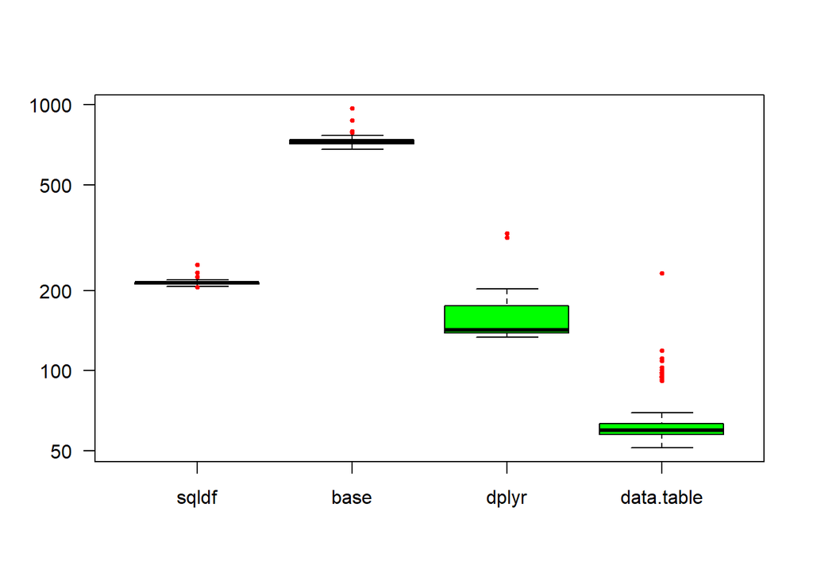

# Podsumowanie

Podczas rozwiązywania zadań najlepiej pracowało mi się z *pakietem dplyr*, stosunkowo dobrze również z *pakietem data.table* - przede wszystkim ze względu na liczne ułatwienia, dodatkowe własności, które one oferują. Najtrudniejsze dla mnie okazało się rozwiązywanie zadań (zwłaszcza tych o ostatnich numerach) używając jedynie *podstawowych funkcji języka R*.